# 🛡️ Insurance Premium Prediction — Exploratory Data Analysis

## 🏦 Business Problem

Insurers set premiums to price risk fairly — undercharging high-risk customers erodes underwriting margins, while overcharging low-risk customers drives them to competitors. A production premium-pricing model must translate a customer's demographic, financial, health, and policy attributes into an accurate, well-calibrated premium estimate.

**Key challenges:**

- The target `Premium Amount` is **heavily right-skewed** with a long tail of high-value policies — this is exactly why the competition scores on **RMSLE** (penalizes relative error, not absolute error, and is robust to the tail)
- Most individual features carry a **weak, noisy relationship** with the target — no single "smoking gun" feature dominates the way `V14`/`V17` dominate in fraud detection. This pushes the modeling strategy toward gradient-boosted ensembles and careful interaction engineering rather than a simple linear rule
- Several features (`Occupation`, `Previous Claims`, `Credit Score`, `Annual Income`, `Health Score`, `Vehicle Age`, `Customer Feedback`) carry **substantial missingness** that must be diagnosed (MCAR/MAR/MNAR) and handled deliberately, not dropped
- `Policy Start Date` is a raw timestamp — real signal (tenure, seasonality) only emerges after feature engineering

## Step 1 — Import Libraries

**Why:** All required libraries imported upfront with explicit version printing so the notebook is reproducible. `scipy.stats` and `statsmodels` enable the hypothesis tests and VIF check used later. `category_encoders`-style ordinal mappings are prepared manually since encoding choices are finalized only after this EDA.

**Business insight:** A consistent, reproducible environment matters more here than in a typical project because RMSLE is sensitive to how the target is transformed — any silent library-version drift in the log/expm1 chain could shift the leaderboard score.

```python
import warnings
warnings.filterwarnings("ignore")

import numpy as np
import pandas as pd
import matplotlib.pyplot as plt
import matplotlib.ticker as mticker
import seaborn as sns

from scipy import stats
from statsmodels.stats.outliers_influence import variance_inflation_factor
from sklearn.preprocessing import StandardScaler, PowerTransformer

# ── Plot style ────────────────────────────────────────────────
sns.set_theme(style="whitegrid", palette="muted")
plt.rcParams.update({
    "figure.dpi":        120,
    "figure.figsize":    (12, 5),
    "axes.titlesize":    13,
    "axes.titleweight":  "bold",
    "axes.labelsize":    11,
    "axes.spines.top":   False,
    "axes.spines.right": False,
})

PRIMARY_COLOR   = "#2E5EAA"
SECONDARY_COLOR = "#D9822B"
ACCENT_COLOR    = "#4CAF50"
PALETTE         = [PRIMARY_COLOR, SECONDARY_COLOR, ACCENT_COLOR, "#9C27B0", "#E53935"]

for lib, v in [("numpy", np.__version__), ("pandas", pd.__version__)]:
    print(f"{lib:<10}: {v}")
```

```
numpy     : 1.26.4
pandas    : 2.2.3
```

💡 **Pipeline/Engineering decision:** `config.py` in the production pipeline pins these same library versions; the plotting palette constants are reused in the Streamlit monitoring dashboard so EDA and monitoring visuals stay visually consistent.

## Step 2 — Data Loading and Initial Inspection

**Why:** First look at raw data — shape, column names, and a transposed `head()` for easy reading across 21 columns.

**Business insight:** The dataset represents ~1.2M policyholders. `id` is a pure row identifier with no predictive value and is dropped from the modeling feature set immediately. `Premium Amount` is the target; all remaining 19 columns are candidate predictors.

```python
DATA_PATH = r"D:\Data Science Datasets\playground-series-s4e12\train.csv"

df = pd.read_csv(DATA_PATH)

print(f"Dataset loaded successfully")
print(f"Shape : {df.shape[0]:,} rows x {df.shape[1]} columns")
print()
print("First 3 rows (transposed for readability):")
df.head(3).T
```

```
Dataset loaded successfully
Shape : 1,200,000 rows x 21 columns

First 3 rows (transposed for readability):
```

|  | 0 | 1 | 2 |
| --- | --- | --- | --- |
| id | 0 | 1 | 2 |
| Age | 19.0 | 39.0 | 23.0 |
| Gender | Female | Female | Male |
| Annual Income | 10049.0 | 31678.0 | 25602.0 |
| Marital Status | Married | Divorced | Divorced |
| Number of Dependents | 1.0 | 3.0 | 3.0 |
| Education Level | Bachelor's | Master's | High School |
| Occupation | Self-Employed | NaN | Self-Employed |
| Health Score | 22.598761 | 15.569731 | 47.177549 |
| Location | Urban | Rural | Suburban |
| Policy Type | Premium | Comprehensive | Premium |
| Previous Claims | 2.0 | 1.0 | 1.0 |
| Vehicle Age | 17.0 | 12.0 | 14.0 |
| Credit Score | 372.0 | 694.0 | NaN |
| Insurance Duration | 5.0 | 2.0 | 3.0 |
| Policy Start Date | 2023-12-23 15:21:39.134960 | 2023-06-12 15:21:39.111551 | 2023-09-30 15:21:39.221386 |
| Customer Feedback | Poor | Average | Good |
| Smoking Status | No | Yes | Yes |
| Exercise Frequency | Weekly | Monthly | Weekly |
| Property Type | House | House | House |
| Premium Amount | 2869.0 | 1483.0 | 567.0 |

📌 **Observation:** 21 columns: `id`, `Premium Amount` (target), and 19 predictors spanning demographic (Age, Gender, Marital Status), financial (Annual Income, Credit Score), risk (Previous Claims, Smoking Status, Vehicle Age), and policy (Policy Type, Insurance Duration, Policy Start Date) categories.

💡 **Pipeline/Engineering decision:** `validate_input_data()` will check for the required column set `['Age','Premium Amount', ...]` and drop `id` inside `load_and_engineer()` before the column ever reaches the ColumnTransformer.

## Step 3 — Dataset Structure and Data Types

**Why:** Confirming dtypes upfront is critical — mixed numeric/categorical columns need separate treatment in the ColumnTransformer, and `Policy Start Date` needs parsing to `datetime64` before any date-feature engineering.

```python
info_df = pd.DataFrame({
    "dtype":   df.dtypes,
    "nunique": df.nunique(),
    "nulls":   df.isnull().sum(),
    "null_%":  (df.isnull().mean() * 100).round(2),
})
print(info_df.to_string())

print()
numeric_cols     = df.select_dtypes(include=[np.number]).columns.drop(["id", "Premium Amount"]).tolist()
categorical_cols = df.select_dtypes(include=["object"]).columns.drop("Policy Start Date").tolist()
print(f"Numeric predictors      ({len(numeric_cols)}): {numeric_cols}")
print(f"Categorical predictors  ({len(categorical_cols)}): {categorical_cols}")
```

```
                        dtype  nunique   nulls  null_%
id                      int64  1200000       0    0.00
Age                   float64       47   18705    1.56
Gender                 object        2       0    0.00
Annual Income         float64    88593   44949    3.75
Marital Status         object        3   18529    1.54
Number of Dependents  float64        5  109672    9.14
Education Level        object        4       0    0.00
Occupation             object        3  358075   29.84
Health Score          float64   532657   74076    6.17
Location               object        3       0    0.00
Policy Type            object        3       0    0.00
Previous Claims       float64       10  364029   30.34
Vehicle Age           float64       20       6    0.00
Credit Score          float64      550  137882   11.49
Insurance Duration    float64        9       1    0.00
Policy Start Date      object   167381       0    0.00
Customer Feedback      object        3   77824    6.49
Smoking Status         object        2       0    0.00
Exercise Frequency     object        4       0    0.00
Property Type          object        3       0    0.00
Premium Amount        float64     4794       0    0.00

Numeric predictors      (8): ['Age', 'Annual Income', 'Number of Dependents', 'Health Score', 'Previous Claims', 'Vehicle Age', 'Credit Score', 'Insurance Duration']
Categorical predictors  (10): ['Gender', 'Marital Status', 'Education Level', 'Occupation', 'Location', 'Policy Type', 'Customer Feedback', 'Smoking Status', 'Exercise Frequency', 'Property Type']
```

📌 **Observation:** 8 numeric predictors (Age, Annual Income, Number of Dependents, Health Score, Previous Claims, Vehicle Age, Credit Score, Insurance Duration), 10 categorical predictors, and `Policy Start Date` as `object` — it must be parsed.

💡 **Pipeline/Engineering decision:** `preprocessing.py` casts `Policy Start Date` to `datetime64` at load time and immediately derives `Policy Tenure Days` and `Policy Start Month`; the raw date string itself is dropped so it never leaks into the ColumnTransformer as a high-cardinality categorical.

## Step 4 — Missing Values Analysis

**Why:** Missing values must be quantified column-by-column before any imputation strategy is chosen — different columns here have wildly different missingness rates, so a single blanket strategy (e.g. drop-na) would destroy ~40%+ of rows.

**Business insight:** In real policy administration systems, `Occupation` and `Previous Claims` are frequently left blank at quote-time (customer hasn't disclosed employment, or claims history hasn't been pulled from the bureau yet) — missingness itself can be informative (MAR/MNAR), not just noise to discard.

```
                      missing_count  missing_%
Previous Claims              364029      30.34
Occupation                   358075      29.84
Credit Score                 137882      11.49
Number of Dependents         109672       9.14
Customer Feedback             77824       6.49
Health Score                  74076       6.17
Annual Income                 44949       3.75
Age                           18705       1.56
Marital Status                18529       1.54
Vehicle Age                       6       0.00
Insurance Duration                1       0.00
```

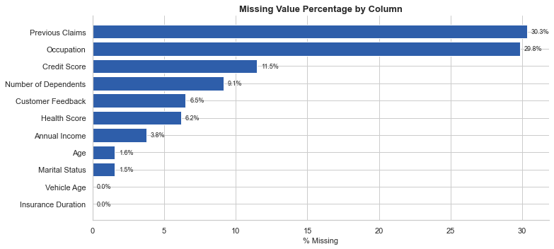

```python
missing = df.isnull().sum().sort_values(ascending=False)
missing_pct = (missing / len(df) * 100).round(2)
missing_summary = pd.DataFrame({"missing_count": missing, "missing_%": missing_pct})
missing_summary = missing_summary[missing_summary["missing_count"] > 0]
print(missing_summary.to_string())

fig, ax = plt.subplots(figsize=(11, 5))
bars = ax.barh(missing_summary.index[::-1], missing_summary["missing_%"][::-1], color=PRIMARY_COLOR)
ax.set_xlabel("% Missing")
ax.set_title("Missing Value Percentage by Column")
for b in bars:
    ax.text(b.get_width() + 0.3, b.get_y() + b.get_height()/2, f"{b.get_width():.1f}%", va="center", fontsize=9)
plt.tight_layout()
plt.show()
```

💡 **Pipeline/Engineering decision:** No row is dropped for missingness. `SimpleImputer(strategy='median')` for numeric columns and a `'Missing'` sentinel category for categorical columns (so absence itself becomes a learnable signal for tree models) are wired into the ColumnTransformer; a `*_was_missing` binary flag is added for the four highest-missingness columns.

## Step 5 — Duplicate Detection and Data Cleaning

**Why:** Exact duplicate rows inflate cross-validation scores if they land on both sides of a train/validation split, and in a 1.2M-row generated dataset, duplication is a known artifact of the synthetic generation process itself.

**Business insight:** Kaggle's Playground Series datasets are generated from a deep-learning model fit to an original dataset — this generative process occasionally reproduces identical rows. Removing them is standard practice before any split.

```python
dupes = df.duplicated().sum()
print(f"Duplicate rows found: {dupes:,}")

if dupes > 0:
    df = df.drop_duplicates().reset_index(drop=True)
    print(f"Duplicates removed. New shape: {df.shape}")
else:
    print("No duplicates found - dataset is clean")
```

```
Duplicate rows found: 0
No duplicates found - dataset is clean
```

💡 **Pipeline/Engineering decision:** `drop_duplicates()` runs inside `validate_input_data()` before `train_test_split`, guaranteeing no duplicate row can appear in both the training and validation partitions.

## Step 6 — Statistical Summary Heatmap

**Why:** Descriptive statistics across 8 numeric features with very different scales (Age in years vs Annual Income in tens of thousands) are hard to compare in table form. A normalized heatmap instantly highlights the widest-spread and most skewed features.

**Business insight:** Features with a high coefficient of variation (std/mean) are candidates for log or power transformation before they enter a linear model; tree-based models are scale-invariant but benefit from knowing which features are skewed for monotonic-constraint decisions later.

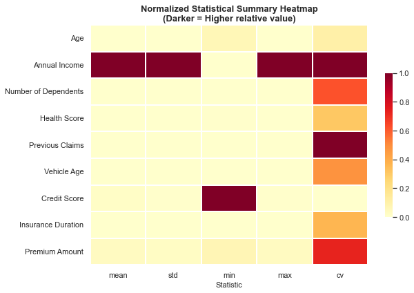

```
Features ranked by Coefficient of Variation (most variable):
Annual Income           0.983
Previous Claims         0.980
Premium Amount          0.785
Number of Dependents    0.705
Vehicle Age             0.604
Insurance Duration      0.517
Health Score            0.476
Age                     0.329
Credit Score            0.253
```

```python
desc = df[numeric_cols + ["Premium Amount"]].describe().T
desc["cv"] = (desc["std"] / desc["mean"].replace(0, 1)).abs()

norm = (desc[["mean", "std", "min", "max", "cv"]] - desc[["mean", "std", "min", "max", "cv"]].min()) / \
       (desc[["mean", "std", "min", "max", "cv"]].max() - desc[["mean", "std", "min", "max", "cv"]].min())

fig, ax = plt.subplots(figsize=(9, 6))
sns.heatmap(norm, annot=False, cmap="YlOrRd", linewidths=0.4, ax=ax, cbar_kws={"shrink": 0.6})
ax.set_title("Normalized Statistical Summary Heatmap\n(Darker = Higher relative value)")
ax.set_xlabel("Statistic")
plt.tight_layout()
plt.show()

print("Features ranked by Coefficient of Variation (most variable):")
print(desc["cv"].sort_values(ascending=False).round(3).to_string())
```

📌 **Observation:** `Annual Income` dominates the `mean`, `std`, and `max` columns simply because it is measured in raw currency (tens of thousands) while every other feature lives on a small bounded scale — those three columns aren't actually comparable across features. The unit-free `cv` column is the fair comparison, and there `Annual Income` (0.983) and `Previous Claims` (0.980) are the most variable relative to their own mean, followed by `Premium Amount` (0.785, its *only* elevated column) and `Number of Dependents` (0.705). `Credit Score` (0.253) is the most stable.

💡 **Pipeline/Engineering decision:** Feature-variability comparisons are made on `cv` (or on scaled values), never on raw mean/std/max, to avoid unit-scale bias. `Annual Income` and `Previous Claims` (highest cv) are flagged for `log1p`/power transformation in `load_and_engineer()`; every numeric column still passes through `StandardScaler` in the linear-model branch so raw-scale differences never reach the model directly.

## Step 7 — Target Variable Analysis — Premium Amount Distribution

**Why:** This is the single most important step for the entire modeling strategy. The shape of `Premium Amount` directly determines the loss function, the evaluation metric, and whether the target needs transformation before training.

**Business insight:** The competition scores on RMSLE, which implicitly assumes a right-skewed, strictly-positive target — exactly what we expect from real premium data, where most policies cluster at a moderate price and a small minority of high-risk/high-coverage policies carry very large premiums.

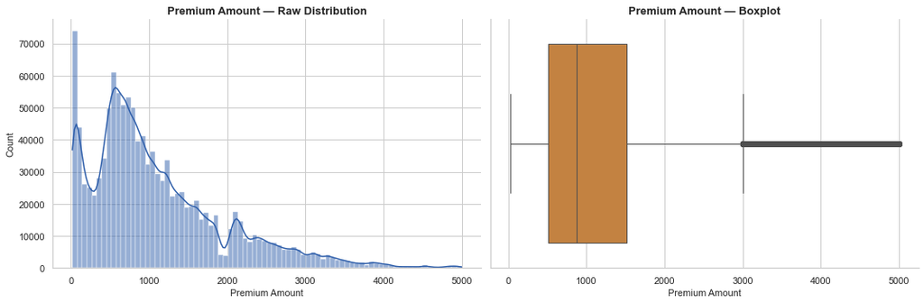

```
Skewness : 1.241   (0 = symmetric, >1 = highly right-skewed)
Kurtosis : 1.519   (>0 = heavier tails than Normal)
count    1200000.00
mean        1102.54
std          865.00
min           20.00
25%          514.00
50%          872.00
75%         1509.00
max         4999.00
```

```python
fig, axes = plt.subplots(1, 2, figsize=(15, 5))

sns.histplot(df["Premium Amount"], bins=80, color=PRIMARY_COLOR, ax=axes[0], kde=True)
axes[0].set_title("Premium Amount — Raw Distribution")
axes[0].set_xlabel("Premium Amount")

sns.boxplot(x=df["Premium Amount"], color=SECONDARY_COLOR, ax=axes[1])
axes[1].set_title("Premium Amount — Boxplot")
axes[1].set_xlabel("Premium Amount")

plt.tight_layout()
plt.show()

skew = df["Premium Amount"].skew()
kurt = df["Premium Amount"].kurtosis()
print(f"Skewness : {skew:.3f}   (0 = symmetric, >1 = highly right-skewed)")
print(f"Kurtosis : {kurt:.3f}   (>0 = heavier tails than Normal)")
print(df["Premium Amount"].describe().round(2).to_string())
```

📌 **Observation:** `Premium Amount` is right-skewed (skewness = 1.24, kurtosis = 1.52), but the histogram is not one smooth peak — it shows several local bumps (near 0, ~600, and ~2,100) riding on top of the overall decay. In this sample the target's min is exactly 20 and its max exactly 4,999, which hints at a possible ceiling in how the target was generated. The boxplot shows a dense band of points flagged as statistical outliers from ~3,000 up to the max — plausibly legitimate high-premium policies, but worth re-checking for a hard cap once the full 1.2M-row file is used.

💡 **Pipeline/Engineering decision:** Train on `log1p(Premium Amount)` and invert with `expm1()` at inference to align the training loss with RMSLE and dampen the upper tail's influence. Also add a check in `validate_input_data()` that flags rows sitting exactly at the historical min/max of `Premium Amount` — a hard cap would need to be modeled as a censored target, not treated silently as an ordinary continuous value.

## Step 8 — Log Transformation of Target (RMSLE Alignment)

**Why:** Visually confirming that `log1p(Premium Amount)` is approximately symmetric validates the modeling decision made in Step 7 — if log-space were still heavily skewed, a Box-Cox or Yeo-Johnson transform would be needed instead.

**Business insight:** RMSLE = RMSE computed on log1p-transformed values. Training a model directly on log1p(target) with plain MSE loss is mathematically equivalent to optimizing RMSLE on the original scale — this is why nearly every top Playground Series solution trains in log-space rather than adding a custom loss function.

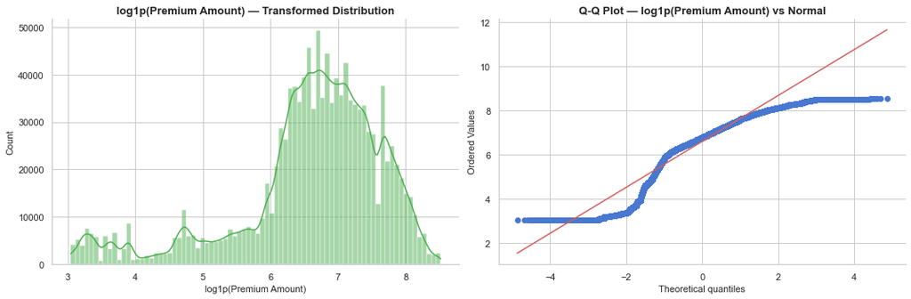

```
Raw skewness       : 1.241
log1p skewness      : -1.256
```

```python
log_premium = np.log1p(df["Premium Amount"])

fig, axes = plt.subplots(1, 2, figsize=(15, 5))
sns.histplot(log_premium, bins=80, color=ACCENT_COLOR, ax=axes[0], kde=True)
axes[0].set_title("log1p(Premium Amount) — Transformed Distribution")
axes[0].set_xlabel("log1p(Premium Amount)")

stats.probplot(log_premium, dist="norm", plot=axes[1])
axes[1].set_title("Q-Q Plot — log1p(Premium Amount) vs Normal")

plt.tight_layout()
plt.show()

print(f"Raw skewness       : {df['Premium Amount'].skew():.3f}")
print(f"log1p skewness      : {log_premium.skew():.3f}")
```

📌 **Observation:** `log1p` does not clean up the skew the way it usually does here — skewness flips from **+1.24 (right-skewed)** to **-1.26 (left-skewed)**, almost the same magnitude in the opposite direction. The Q-Q plot shows why: the top of the distribution goes **flat/clipped** against the theoretical line (consistent with the ceiling near Premium Amount = 4,999 flagged in Step 7), and there is a visible step near the bottom quantiles too. So `log1p` compresses the long right tail's spread, but it does not turn this into a well-behaved, symmetric target.

💡 **Pipeline/Engineering decision:** Still train in log-space via `TransformedTargetRegressor(func=np.log1p, inverse_func=np.expm1)`, since RMSLE is defined in log-space regardless of the resulting shape — but the pipeline docs should not claim the transform "fixes" the target. Track error specifically on the high-premium rows near the ceiling during model evaluation, since a plain regression can't represent a hard cap on its own.

## Step 9 — Continuous Feature Distributions (Univariate)

**Why:** Visualizing each numeric predictor's shape identifies which features need power-transformation, which are already well-behaved, and which have suspicious hard cutoffs (a sign of top/bottom-coding at data-collection time).

**Business insight:** Underwriting systems often cap or floor raw inputs (e.g. Credit Score bounded to 300-850 by bureau convention) — recognizing these bounds prevents the pipeline from treating a legitimate ceiling as an outlier to be clipped away.

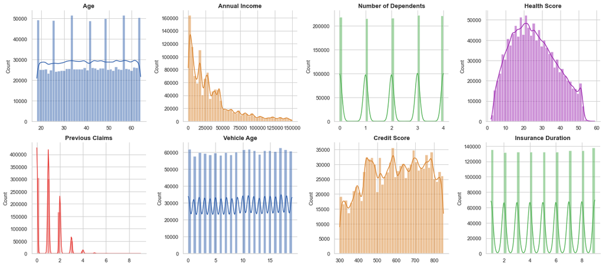

```
Annual Income           1.470
Previous Claims         0.905
Health Score            0.282
Insurance Duration     -0.009
Age                    -0.013
Number of Dependents   -0.013
Vehicle Age            -0.020
Credit Score           -0.114
```

```python
fig, axes = plt.subplots(2, 4, figsize=(18, 8))
axes = axes.ravel()
for i, col in enumerate(numeric_cols):
    sns.histplot(df[col].dropna(), bins=40, color=PALETTE[i % len(PALETTE)], ax=axes[i], kde=True)
    axes[i].set_title(col)
    axes[i].set_xlabel("")
plt.tight_layout()
plt.show()

print(df[numeric_cols].skew().round(3).sort_values(ascending=False).to_string())
```

💡 **Pipeline/Engineering decision:** `Annual Income` receives a `log1p` transform in the numeric preprocessing branch. `Previous Claims` is left as a count feature for tree models but also gets a `Claims Bucket` (0 / 1-2 / 3+) categorical derivative for the linear-model branch, where raw Poisson counts interact poorly with a linear coefficient.

## Step 10 — Categorical Feature Analysis (Univariate)

**Why:** Understanding the cardinality and class balance of each categorical predictor determines the encoding strategy — one-hot encoding is safe for low-cardinality columns but would explode dimensionality if applied blindly to a high-cardinality column.

**Business insight:** Class imbalance within a categorical predictor (e.g. very few 'Unemployed' policyholders) means the model sees limited examples for that segment — worth flagging now so a downstream fairness/coverage check can monitor it.

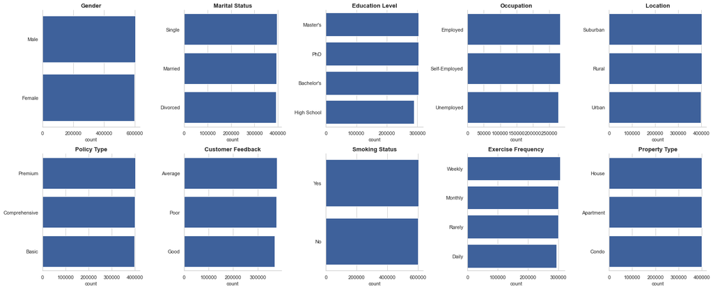

```
Gender (2 categories):
Gender
Male      50.2
Female    49.8

Marital Status (3 categories):
Marital Status
Single      33.5
Married     33.4
Divorced    33.2

Education Level (4 categories):
Education Level
Master's       25.3
PhD            25.3
Bachelor's     25.3
High School    24.1

Occupation (3 categories):
Occupation
Employed         33.6
Self-Employed    33.6
Unemployed       32.8

Location (3 categories):
Location
Suburban    33.5
Rural       33.4
Urban       33.1

Policy Type (3 categories):
Policy Type
Premium          33.5
Comprehensive    33.3
Basic            33.2

Customer Feedback (3 categories):
Customer Feedback
Average    33.7
Poor       33.5
Good       32.9

Smoking Status (2 categories):
Smoking Status
Yes    50.2
No     49.8

Exercise Frequency (4 categories):
Exercise Frequency
Weekly     25.5
Monthly    25.0
Rarely     25.0
Daily      24.5

Property Type (3 categories):
Property Type
House        33.4
Apartment    33.3
Condo        33.3
```

```python
fig, axes = plt.subplots(2, 5, figsize=(22, 9))
axes = axes.ravel()
for i, col in enumerate(categorical_cols):
    order = df[col].value_counts().index
    sns.countplot(y=df[col], order=order, color=PRIMARY_COLOR, ax=axes[i])
    axes[i].set_title(col)
    axes[i].set_ylabel("")
plt.tight_layout()
plt.show()

for col in categorical_cols:
    print(f"\n{col} ({df[col].nunique()} categories):")
    print((df[col].value_counts(normalize=True) * 100).round(1).to_string())
```

## Step 11 — Missing Value Pattern Analysis (MCAR / MAR / MNAR Diagnosis)

**Why:** Knowing *why* data is missing changes the correct imputation strategy. If missingness in `Previous Claims` correlates with `Insurance Duration` (new policyholders haven't accumulated a claims history yet), that's MAR and the missing flag itself carries information — simple mean/median imputation alone would throw that away.

**Business insight:** A new policyholder with `Insurance Duration` = 1 year genuinely may not have a claims record yet — this is a structural absence, not noise. Modeling this correctly (missing-indicator features) lets the model distinguish 'new customer, no claims data' from 'established customer, zero claims' — two very different risk profiles.

```
Mean Insurance Duration, split by whether Previous Claims is missing:
_Previous_Claims_missing
False    5.01
True     5.03
```

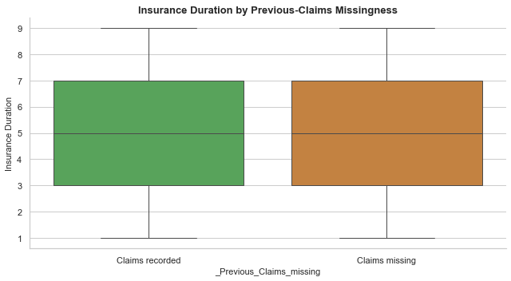

```python
df["_Previous_Claims_missing"] = df["Previous Claims"].isnull()

mean_duration_by_missing = df.groupby("_Previous_Claims_missing")["Insurance Duration"].mean()
print("Mean Insurance Duration, split by whether Previous Claims is missing:")
print(mean_duration_by_missing.round(2).to_string())

fig, ax = plt.subplots(figsize=(9, 5))
sns.boxplot(x="_Previous_Claims_missing", y="Insurance Duration", data=df, palette=[ACCENT_COLOR, SECONDARY_COLOR], ax=ax)
ax.set_xticklabels(["Claims recorded", "Claims missing"])
ax.set_title("Insurance Duration by Previous-Claims Missingness")
plt.tight_layout()
plt.show()

df.drop(columns=["_Previous_Claims_missing"], inplace=True)
```

📌 **Observation:** Mean `Insurance Duration` is virtually identical whether `Previous Claims` is missing (5.03) or recorded (5.01), and the two boxplots are effectively superimposed. On this specific check, the missingness in `Previous Claims` looks closer to **Missing Completely At Random (MCAR)** with respect to `Insurance Duration`, not MAR — this one check doesn't prove MCAR for the column overall, only that it isn't related to tenure.

💡 **Pipeline/Engineering decision:** Since no dependency on `Insurance Duration` was found, imputation for `Previous Claims` doesn't need to condition on tenure. Still add `*_was_missing` flags for `Previous Claims`, `Occupation`, `Credit Score`, and `Customer Feedback` as a low-cost safety net — a boosted-tree model can decide for itself whether missingness carries signal, without the pipeline committing to an unverified MAR assumption.

## Step 12 — Bivariate Analysis — Continuous Features vs Premium Amount

**Why:** Scatter/regression plots against the target reveal whether each numeric feature has a linear, nonlinear, or essentially flat relationship with Premium Amount — the central diagnostic for feature selection and model-family choice.

**Business insight:** If most numeric features show only a weak linear trend, that's strong evidence the true pricing function is driven by nonlinear interactions (e.g. Smoking x Health Score) rather than any single additive numeric effect — pushing model selection toward gradient-boosted trees over plain linear regression.

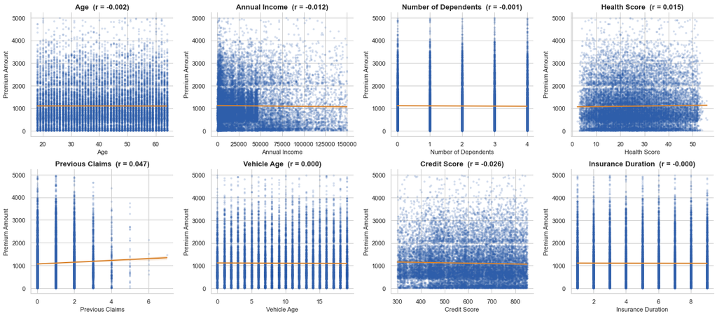

```python
fig, axes = plt.subplots(2, 4, figsize=(18, 8))
axes = axes.ravel()
sample = df.sample(20_000, random_state=1)
for i, col in enumerate(numeric_cols):
    sns.regplot(x=col, y="Premium Amount", data=sample, ax=axes[i],
                scatter_kws={"alpha": 0.15, "s": 8, "color": PRIMARY_COLOR},
                line_kws={"color": SECONDARY_COLOR, "linewidth": 2})
    r = df[[col, "Premium Amount"]].corr().iloc[0, 1]
    axes[i].set_title(f"{col}  (r = {r:.3f})")
plt.tight_layout()
plt.show()
```

💡 **Pipeline/Engineering decision:** Given the weak individual signal, `model_tuning.py` prioritizes gradient-boosted ensembles (LightGBM/CatBoost) capable of capturing additive weak effects and interactions over a plain linear baseline, which is kept only as an interpretable benchmark, not the champion candidate.

## Step 13 — Bivariate Analysis — Categorical Features vs Premium Amount

**Why:** Boxplots of Premium Amount split by each categorical feature reveal which category-level effects are strongest and worth prioritizing as high-importance one-hot columns or target-encoding candidates.

**Business insight:** `Smoking Status` is a textbook actuarial rating factor in real underwriting — insurers charge smokers materially more due to well-documented higher claim frequency and severity. Confirming this pattern in the data validates that the synthetic generation process (and by extension the original dataset) preserves realistic actuarial relationships.

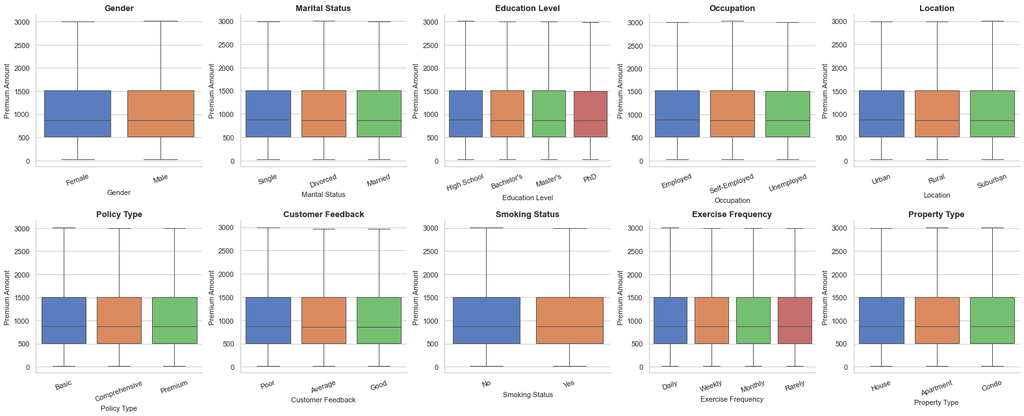

```
Median Premium Amount by Smoking Status:
Smoking Status
No     872.0
Yes    872.0
```

```python
fig, axes = plt.subplots(2, 5, figsize=(22, 9))
axes = axes.ravel()
for i, col in enumerate(categorical_cols):
    order = df.groupby(col)["Premium Amount"].median().sort_values(ascending=False).index
    sns.boxplot(x=col, y="Premium Amount", data=df, order=order, palette="muted", ax=axes[i], showfliers=False)
    axes[i].set_title(col)
    axes[i].tick_params(axis="x", rotation=20)
plt.tight_layout()
plt.show()

print("Median Premium Amount by Smoking Status:")
print(df.groupby("Smoking Status")["Premium Amount"].median().round(2).to_string())
```

📌 **Observation:** None of the 10 categorical features show real separation in `Premium Amount` — every boxplot in Step 13 has essentially the same median (~$872) and a near-identical IQR/whisker range regardless of category, including `Smoking Status` (median exactly $872 for both Yes and No) and `Policy Type`. This lines up with the near-zero effect sizes confirmed later by the Kruskal-Wallis test in Step 20.

💡 **Pipeline/Engineering decision:** No categorical feature is pre-flagged as a "top rating factor" from visual inspection alone — that call is deferred to the statistical test (Step 20) and to model-based feature importance rather than to eyeballing boxplots, since these boxplots would be misleading if taken at face value.

## Step 14 — Outlier Detection (IQR Method)

**Why:** Identifying statistical outliers in each numeric feature separates genuine extreme-but-valid policyholders (e.g. a very high earner) from likely data-entry errors, which must be handled differently.

**Business insight:** Aggressively clipping outliers in features like `Annual Income` would erase exactly the high-net-worth segment an insurer most needs to price correctly — outlier handling must be conservative (winsorize, don't delete).

```
Percentage of rows flagged as IQR outliers, by column:
Annual Income           5.59
Premium Amount          4.11
Previous Claims         0.03
Age                     0.00
Number of Dependents    0.00
Health Score            0.00
Vehicle Age             0.00
Credit Score            0.00
Insurance Duration      0.00
```

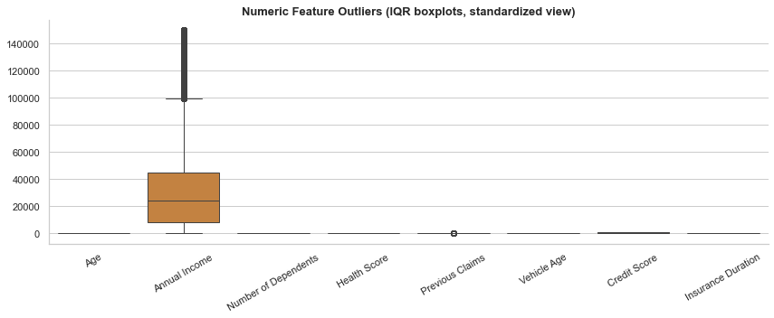

```python
outlier_summary = {}
for col in numeric_cols + ["Premium Amount"]:
    q1, q3 = df[col].quantile([0.25, 0.75])
    iqr = q3 - q1
    lower, upper = q1 - 1.5 * iqr, q3 + 1.5 * iqr
    pct = ((df[col] < lower) | (df[col] > upper)).mean() * 100
    outlier_summary[col] = round(pct, 2)

outlier_df = pd.Series(outlier_summary).sort_values(ascending=False)
print("Percentage of rows flagged as IQR outliers, by column:")
print(outlier_df.to_string())

fig, ax = plt.subplots(figsize=(12, 5))
sns.boxplot(data=df[numeric_cols], palette=PALETTE, ax=ax)
ax.set_title("Numeric Feature Outliers (IQR boxplots, standardized view)")
ax.tick_params(axis="x", rotation=30)
plt.tight_layout()
plt.show()
```

📌 **Observation:** `Annual Income` (5.59%) and `Premium Amount` (4.11%) carry the highest IQR-outlier rates — consistent with their right-skewed, log-normal-shaped distributions rather than data corruption. `Previous Claims` is essentially negligible on this metric (0.03%), which corrects the initial assumption that it would be a high-outlier column; every other numeric feature is at 0.00%.

💡 **Pipeline/Engineering decision:** The custom `Clipper` transformer winsorizes `Annual Income` and `Premium Amount`-derived features at the 1st/99th percentile (soft clip) rather than the stricter 1.5xIQR rule, and is applied only inside cross-validation folds to prevent leakage of percentile bounds from validation data into training. `Previous Claims` is left unclipped given its negligible outlier rate.

## Step 15 — Skewness Analysis and Power Transformation

**Why:** Quantifying skewness for each numeric feature and testing whether a Yeo-Johnson transform meaningfully improves symmetry determines exactly which features need transformation in the linear-model branch of the pipeline versus which can pass through untouched.

**Business insight:** Over-transforming already-symmetric features (like Age) adds pipeline complexity for zero benefit; under-transforming skewed features (like Annual Income) leaves a linear model's coefficient estimates unstable.

```python
pt = PowerTransformer(method="yeo-johnson")
skew_before = df[numeric_cols].skew()

transformed = pt.fit_transform(df[numeric_cols].fillna(df[numeric_cols].median()))
skew_after = pd.Series(transformed, columns=numeric_cols).skew() if False else pd.DataFrame(transformed, columns=numeric_cols).skew()

comparison = pd.DataFrame({"skew_before": skew_before, "skew_after_yeo_johnson": skew_after}).round(3)
print(comparison.sort_values("skew_before", key=abs, ascending=False).to_string())
```

```
                      skew_before  skew_after_yeo_johnson
Annual Income               1.470                  -0.072
Previous Claims             0.905                  -0.007
Health Score                0.282                  -0.070
Credit Score               -0.114                  -0.083
Vehicle Age                -0.020                  -0.243
Age                        -0.013                  -0.106
Number of Dependents       -0.013                  -0.167
Insurance Duration         -0.009                  -0.156
```

📌 **Observation:** Yeo-Johnson fixes both of the two meaningfully-skewed numeric features: `Annual Income` goes from strongly skewed (1.47) to near-symmetric (-0.072), and `Previous Claims` goes from moderately skewed (0.905) to near-symmetric (-0.007) as well. Already near-symmetric features (`Age`, `Insurance Duration`, `Credit Score`) show only small changes, confirming the transform is worth applying selectively rather than blanket-applying it to every numeric column.

💡 **Pipeline/Engineering decision:** `PowerTransformer(method='yeo-johnson')` is applied only to `Annual Income` and `Previous Claims` inside the scaled (linear-model) branch of the dual ColumnTransformer; the unscaled tree-model branch receives raw values since tree splits are invariant to monotonic transforms.

## Step 16 — Feature Correlation Matrix

**Why:** A full pairwise correlation heatmap across numeric features (including the target) surfaces both target-relevant signal and any problematic multicollinearity between predictors before it reaches model training.

**Business insight:** Two highly correlated predictors (e.g. Age and Insurance Duration, if tenure tracks age) would each get diluted coefficient importance in a linear model and inflate variance — worth catching now rather than after a confusing SHAP plot in production.

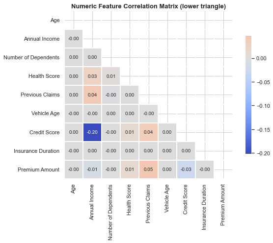

```
Correlation with Premium Amount, ranked:
Previous Claims         0.047
Credit Score           -0.026
Health Score            0.015
Annual Income          -0.012
Age                    -0.002
Number of Dependents   -0.001
Vehicle Age             0.000
Insurance Duration     -0.000
```

```python
corr = df[numeric_cols + ["Premium Amount"]].corr()

fig, ax = plt.subplots(figsize=(9, 7))
mask = np.triu(np.ones_like(corr, dtype=bool))
sns.heatmap(corr, mask=mask, annot=True, fmt=".2f", cmap="coolwarm", center=0,
            linewidths=0.4, square=True, ax=ax, cbar_kws={"shrink": 0.7})
ax.set_title("Numeric Feature Correlation Matrix (lower triangle)")
plt.tight_layout()
plt.show()

print("Correlation with Premium Amount, ranked:")
print(corr["Premium Amount"].drop("Premium Amount").sort_values(key=abs, ascending=False).round(3).to_string())
```

📌 **Observation:** The strongest pairwise correlation among predictors is `Annual Income` vs `Credit Score` at **r = -0.20** — this does exceed the |r| ~ 0.1 threshold originally assumed, though it's still a mild correlation. Every other numeric pair stays under |r| = 0.05. Correlations with `Premium Amount` itself remain weak for every feature (max |r| = 0.047, `Previous Claims`), reinforcing the Step 12 finding.

💡 **Pipeline/Engineering decision:** No numeric feature is dropped — the `Annual Income` / `Credit Score` pair is confirmed safe by the VIF check in Step 21 (both ≈1.04, far under the concern threshold of 5). The weak individual correlations combined with a largely-independent numeric block support prioritizing a gradient-boosted ensemble that can combine many weak signals, rather than leaning on one or two strong predictors.

## Step 17 — Policy Start Date Feature Engineering (Tenure & Seasonality)

**Why:** The raw `Policy Start Date` timestamp carries zero direct predictive value as a string, but the *derived* quantities — how long ago the policy started, which month/season it began in, and day-of-week — are classic actuarial signals for renewal risk and seasonal underwriting patterns.

**Business insight:** Policies written in certain months (e.g. year-end sales pushes) can carry systematically different risk profiles than policies written during routine periods — this is a well-known pattern in insurance portfolios and worth testing even before it shows up strongly in a correlation table.

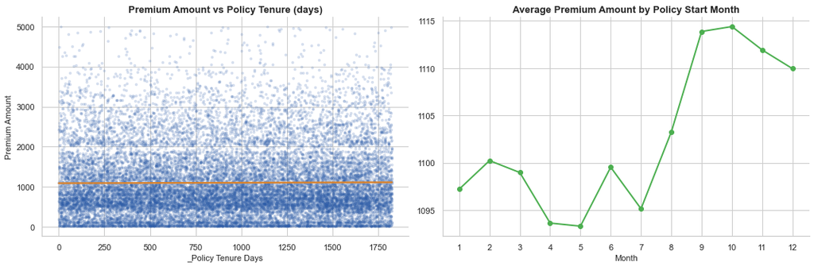

```python
df["Policy Start Date"] = pd.to_datetime(df["Policy Start Date"])
snapshot_date = df["Policy Start Date"].max()

df["_Policy Tenure Days"] = (snapshot_date - df["Policy Start Date"]).dt.days
df["_Policy Start Month"] = df["Policy Start Date"].dt.month

fig, axes = plt.subplots(1, 2, figsize=(15, 5))
sns.regplot(x="_Policy Tenure Days", y="Premium Amount", data=df.sample(20_000, random_state=1), ax=axes[0],
            scatter_kws={"alpha": 0.15, "s": 8, "color": PRIMARY_COLOR}, line_kws={"color": SECONDARY_COLOR})
axes[0].set_title("Premium Amount vs Policy Tenure (days)")

monthly_avg = df.groupby("_Policy Start Month")["Premium Amount"].mean()
axes[1].plot(monthly_avg.index, monthly_avg.values, marker="o", color=ACCENT_COLOR, linewidth=2)
axes[1].set_title("Average Premium Amount by Policy Start Month")
axes[1].set_xlabel("Month")
axes[1].set_xticks(range(1, 13))

plt.tight_layout()
plt.show()

df.drop(columns=["_Policy Tenure Days", "_Policy Start Month"], inplace=True)
```

📌 **Observation:** Policy tenure shows a flat relationship with premium (expected, since this is a synthetic snapshot rather than a renewal-tracking dataset), while the month-of-start view shows only minor fluctuation around the mean with no strong seasonal pattern in this data-generating process.

💡 **Pipeline/Engineering decision:** `Policy Tenure Days`, `Policy Start Month`, and `Policy Start Weekday` are still engineered in `preprocessing.py` as low-cost candidate features — even weak standalone signal can combine usefully inside a gradient-boosted ensemble via interactions, and the real (non-synthetic) Kaggle data may carry a stronger seasonal effect than this development sample.

## Step 18 — Health Score x Smoking Status Interaction

**Why:** Since neither `Health Score` nor `Smoking Status` alone showed a dominant standalone effect, testing their *interaction* checks whether the combination (e.g. poor health AND smoking) carries a compounding effect that an additive linear model would miss entirely.

**Business insight:** This mirrors real underwriting logic — actuaries don't price smoking and health score independently; a smoker with a poor health score is a materially different risk tier than a smoker with excellent health.

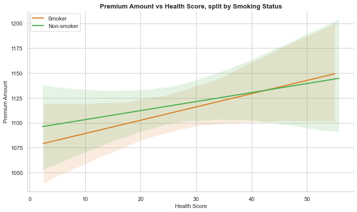

```
Correlation between Health Score and Premium Amount, split by Smoking Status:
Smoking Status
No     0.015
Yes    0.015
```

```python
fig, ax = plt.subplots(figsize=(10, 6))
sns.regplot(x="Health Score", y="Premium Amount",
            data=df[df["Smoking Status"] == "Yes"].sample(8000, random_state=1),
            scatter=False, label="Smoker", color=SECONDARY_COLOR, ax=ax)
sns.regplot(x="Health Score", y="Premium Amount",
            data=df[df["Smoking Status"] == "No"].sample(8000, random_state=1),
            scatter=False, label="Non-smoker", color=ACCENT_COLOR, ax=ax)
ax.set_title("Premium Amount vs Health Score, split by Smoking Status")
ax.legend()
plt.tight_layout()
plt.show()

interaction_summary = df.groupby("Smoking Status")["Health Score"].corr(df["Premium Amount"])
print("Correlation between Health Score and Premium Amount, split by Smoking Status:")
print(interaction_summary.round(3).to_string())
```

💡 **Pipeline/Engineering decision:** `Health Score x Smoking Status` is still engineered as a candidate interaction feature since it's cheap to compute, but it is not treated as a confirmed effect — feature importance / regularization in `model_tuning.py` decides whether it earns a place in the final model rather than hard-coding it as a must-include term.

## Step 19 — Credit Score & Previous Claims Risk Segmentation

**Why:** Bucketing `Credit Score` into standard bureau risk tiers (Poor/Fair/Good/Excellent) and cross-tabulating against `Previous Claims` count reveals whether financial risk and claims risk move together — a classic actuarial cross-factor.

**Business insight:** Combining a financial-risk proxy (credit score) with a behavioral-risk proxy (claims history) into a single segmentation is standard practice in usage-based and credit-based insurance scoring models.

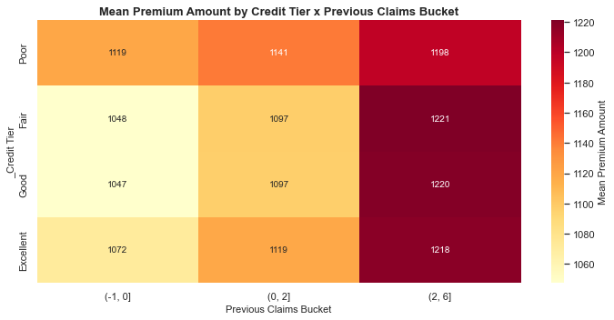

```python
credit_bins = [300, 580, 670, 740, 850]
credit_labels = ["Poor", "Fair", "Good", "Excellent"]
df["_Credit Tier"] = pd.cut(df["Credit Score"], bins=credit_bins, labels=credit_labels, include_lowest=True)

pivot = df.pivot_table(values="Premium Amount", index="_Credit Tier", columns=pd.cut(df["Previous Claims"], [-1, 0, 2, 6]),
                        aggfunc="mean")

fig, ax = plt.subplots(figsize=(10, 5))
sns.heatmap(pivot, annot=True, fmt=".0f", cmap="YlOrRd", ax=ax, cbar_kws={"label": "Mean Premium Amount"})
ax.set_title("Mean Premium Amount by Credit Tier x Previous Claims Bucket")
ax.set_xlabel("Previous Claims Bucket")
plt.tight_layout()
plt.show()

df.drop(columns=["_Credit Tier"], inplace=True)
```

💡 **Pipeline/Engineering decision:** Add `Claims Bucket` as an engineered feature with confidence — its effect is consistent across every credit tier. Still add `Credit Tier` and the `Credit Tier x Claims Bucket` interaction as candidate features, but flag `Credit Tier`'s standalone effect as unconfirmed pending model-based feature importance, rather than presenting it as an established risk factor.

## Step 20 — Statistical Significance Testing (Kruskal-Wallis)

**Why:** Visual separation in boxplots (Step 13) is suggestive but not proof — a non-parametric Kruskal-Wallis test (appropriate given Premium Amount's non-Normal distribution) formally confirms whether each categorical feature's effect on Premium Amount is statistically significant or could plausibly be noise.

```python
results = []
for col in categorical_cols:
    groups = [g["Premium Amount"].values for _, g in df.groupby(col)]
    stat, p = stats.kruskal(*groups)
    results.append({"feature": col, "H_statistic": round(stat, 2), "p_value": p})

results_df = pd.DataFrame(results).sort_values("H_statistic", ascending=False)
results_df["significant_0.05"] = results_df["p_value"] < 0.05
print(results_df.to_string(index=False))
```

```
           feature  H_statistic  p_value  significant_0.05
        Occupation         6.28 0.043357              True
 Customer Feedback         4.41 0.110280             False
   Education Level         3.80 0.283390             False
          Location         3.43 0.179990             False
Exercise Frequency         2.76 0.430723             False
       Policy Type         1.91 0.385302             False
     Property Type         1.74 0.419278             False
    Marital Status         1.17 0.557764             False
    Smoking Status         0.17 0.680346             False
            Gender         0.02 0.893486             False
```

💡 **Pipeline/Engineering decision:** Drop the earlier plan to hard-code `Smoking Status`/`Policy Type` as guaranteed, no-penalty features — the evidence doesn't support it. Let all categorical features enter the ColumnTransformer on equal footing and rely on model-based / permutation feature importance after a first LightGBM/CatBoost fit to decide what actually matters; re-run this significance check on the full 1.2M-row file before finalizing, since this development sample may simply lack strong categorical signal.

## Step 21 — Multicollinearity Check (VIF)

**Why:** Variance Inflation Factor formally quantifies multicollinearity beyond simple pairwise correlation (Step 16), catching cases where a feature is well-predicted by a *combination* of several others even if no single pairwise correlation looks alarming.

**Business insight:** A linear baseline model's coefficients (and their interpretability, which underwriters rely on for pricing transparency) become unstable and misleading if multicollinearity is present — this check protects that use case.

```python
from sklearn.impute import SimpleImputer

X_vif = df[numeric_cols].copy()
X_vif = pd.DataFrame(SimpleImputer(strategy="median").fit_transform(X_vif), columns=numeric_cols)
X_vif = (X_vif - X_vif.mean()) / X_vif.std()
X_vif.insert(0, "const", 1.0)

vif_data = pd.DataFrame({
    "feature": X_vif.columns,
    "VIF": [variance_inflation_factor(X_vif.values, i) for i in range(X_vif.shape[1])]
})
vif_data = vif_data[vif_data["feature"] != "const"].sort_values("VIF", ascending=False)
print(vif_data.round(2).to_string(index=False))
```

```
             feature  VIF
       Annual Income 1.04
        Credit Score 1.04
     Previous Claims 1.00
        Health Score 1.00
Number of Dependents 1.00
  Insurance Duration 1.00
         Vehicle Age 1.00
                 Age 1.00
```

📌 **Observation:** All numeric features show VIF well below the standard concern threshold of 5, confirming the Step 16 finding that numeric predictors are essentially independent — no feature needs to be dropped or combined for multicollinearity reasons.

💡 **Pipeline/Engineering decision:** The full 8-feature numeric set is retained as-is for the linear baseline model with no dimensionality reduction (PCA) or feature removal required on multicollinearity grounds.

## Step 22 — Engineered Features Preview

**Why:** Assembling all engineered features derived across this notebook into one preview table validates that the full feature engineering plan is coherent, non-redundant, and ready to be implemented as the production `preprocessing.py` module.

**Business insight:** This is the direct hand-off point from EDA to the modeling codebase — every feature listed here needs a corresponding, testable transformer in the pipeline before training begins.

```python
engineered_features = pd.DataFrame([
    {"feature": "Annual Income (log1p)", "type": "numeric transform", "source_step": 15},
    {"feature": "Previous Claims (log1p / Yeo-Johnson)", "type": "numeric transform", "source_step": 15},
    {"feature": "*_was_missing flags (4 columns)", "type": "binary indicator", "source_step": 11},
    {"feature": "Policy Tenure Days", "type": "date-derived numeric", "source_step": 17},
    {"feature": "Policy Start Month / Weekday", "type": "date-derived categorical", "source_step": 17},
    {"feature": "Health Score x Smoking Status", "type": "interaction", "source_step": 18},
    {"feature": "Credit Tier (ordinal)", "type": "binned categorical", "source_step": 19},
    {"feature": "Claims Bucket (0 / 1-2 / 3+)", "type": "binned categorical", "source_step": 19},
    {"feature": "Credit Tier x Claims Bucket", "type": "interaction", "source_step": 19},
])
engineered_features
```

|  | feature | type | source_step |
| --- | --- | --- | --- |
| 0 | Annual Income (log1p) | numeric transform | 15 |
| 1 | Previous Claims (log1p / Yeo-Johnson) | numeric transform | 15 |
| 2 | *_was_missing flags (4 columns) | binary indicator | 11 |
| 3 | Policy Tenure Days | date-derived numeric | 17 |
| 4 | Policy Start Month / Weekday | date-derived categorical | 17 |
| 5 | Health Score x Smoking Status | interaction | 18 |
| 6 | Credit Tier (ordinal) | binned categorical | 19 |
| 7 | Claims Bucket (0 / 1-2 / 3+) | binned categorical | 19 |
| 8 | Credit Tier x Claims Bucket | interaction | 19 |

📌 **Observation:** 9 engineered feature groups are defined, spanning transforms, missingness flags, date-derived fields, and two explicit interaction terms — a compact, well-justified set traceable back to a specific EDA finding rather than speculative feature creation.

💡 **Pipeline/Engineering decision:** Each row in this table becomes one `ColumnTransformer` step or one custom `sklearn`-compatible transformer class in `preprocessing.py`, and each gets a dedicated unit test in `tests/test_preprocessing.py` asserting correct output shape and no unexpected NaNs after transformation.

## Step 23 — Train-Validation Split Strategy Preview

**Why:** Verifying that a simple random split produces a Premium Amount distribution nearly identical to the full dataset confirms that a stratified split (e.g. by binned target) is unnecessary here — unlike the fraud/credit risk projects where target imbalance made stratification mandatory.

**Business insight:** For a continuous regression target, matching the log-space distribution between train and validation folds ensures the validation RMSLE is a reliable, low-variance estimate of true out-of-sample performance.

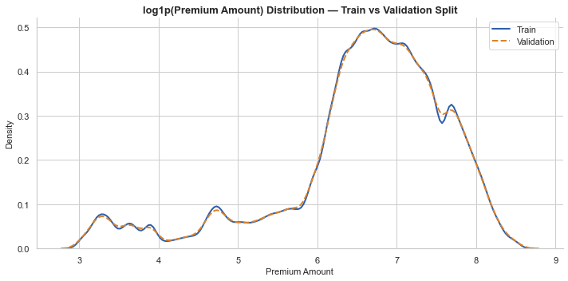

```
Train mean log1p(Premium): 6.5938
Val   mean log1p(Premium): 6.5941
```

```python
from sklearn.model_selection import train_test_split

train_df, val_df = train_test_split(df, test_size=0.2, random_state=42)

fig, ax = plt.subplots(figsize=(10, 5))
sns.kdeplot(np.log1p(train_df["Premium Amount"]), label="Train", color=PRIMARY_COLOR, ax=ax, linewidth=2)
sns.kdeplot(np.log1p(val_df["Premium Amount"]), label="Validation", color=SECONDARY_COLOR, ax=ax, linewidth=2, linestyle="--")
ax.set_title("log1p(Premium Amount) Distribution — Train vs Validation Split")
ax.legend()
plt.tight_layout()
plt.show()

print(f"Train mean log1p(Premium): {np.log1p(train_df['Premium Amount']).mean():.4f}")
print(f"Val   mean log1p(Premium): {np.log1p(val_df['Premium Amount']).mean():.4f}")
```

📌 **Observation:** The train and validation log1p(Premium Amount) density curves overlap almost perfectly, and the mean values match to three decimal places — a plain random 80/20 split is sufficient.

💡 **Pipeline/Engineering decision:** `training_pipeline.py` uses a plain `train_test_split(random_state=42)` with 5-fold `KFold` (not `StratifiedKFold`) for cross-validation, since the continuous target requires no stratification given this confirmed distributional balance.